# AIML_ML_Project_full_code_notebook_Final

## Problem Statement

### Context

AllLife Bank is a US bank that has a growing customer base. The majority of these customers are liability customers (depositors) with varying sizes of deposits. The number of customers who are also borrowers (asset customers) is quite small, and the bank is interested in expanding this base rapidly to bring in more loan business and in the process, earn more through the interest on loans. In particular, the management wants to explore ways of converting its liability customers to personal loan customers (while retaining them as depositors).

A campaign that the bank ran last year for liability customers showed a healthy conversion rate of over 9% success. This has encouraged the retail marketing department to devise campaigns with better target marketing to increase the success ratio.

You as a Data scientist at AllLife bank have to build a model that will help the marketing department to identify the potential customers who have a higher probability of purchasing the loan.

### Objective

To predict whether a liability customer will buy personal loans, to understand which customer attributes are most significant in driving purchases, and identify which segment of customers to target more.

### Data Dictionary

- `ID`: Customer ID
- `Age`: Customer’s age in completed years
- `Experience`: #years of professional experience
- `Income`: Annual income of the customer (in thousand dollars)
- `ZIP Code`: Home Address ZIP code.
- `Family`: the Family size of the customer
- `CCAvg`: Average spending on credit cards per month (in thousand dollars)
- `Education`: Education Level. 1: Undergrad; 2: Graduate;3: Advanced/Professional
- `Mortgage`: Value of house mortgage if any. (in thousand dollars)
- `Personal_Loan`: Did this customer accept the personal loan offered in the last campaign? (0: No, 1: Yes)
- `Securities_Account`: Does the customer have securities account with the bank? (0: No, 1: Yes)
- `CD_Account`: Does the customer have a certificate of deposit (CD) account with the bank? (0: No, 1: Yes)
- `Online`: Do customers use internet banking facilities? (0: No, 1: Yes)
- `CreditCard`: Does the customer use a credit card issued by any other Bank (excluding All life Bank)? (0: No, 1: Yes)

## Importing necessary libraries

```python
# Installing the libraries with the specified version.
#!pip install numpy==1.25.2 pandas==1.5.3 matplotlib==3.7.1 seaborn==0.13.1 scikit-learn==1.2.2 sklearn-pandas==2.2.0 -q --user
```

**Note**:

1. After running the above cell, kindly restart the notebook kernel (for Jupyter Notebook) or runtime (for Google Colab), write the relevant code for the project from the next cell, and run all cells sequentially from the next cell.
2. On executing the above line of code, you might see a warning regarding package dependencies. This error message can be ignored as the above code ensures that all necessary libraries and their dependencies are maintained to successfully execute the code in this notebook.

```python
# Libraries to help with reading and manipulating data
import pandas as pd
import numpy as np

# libaries to help with data visualization
import matplotlib.pyplot as plt
import seaborn as sns
import plotly.express as px

# Removes the limit for the number of displayed columns
pd.set_option("display.max_columns", None)
# Sets the limit for the number of displayed rows
pd.set_option("display.max_rows", 200)

# to scale the data using z-score
from sklearn.preprocessing import StandardScaler

# to perform k-means clustering and compute silhouette scores
from sklearn.cluster import KMeans
from sklearn.metrics import silhouette_score

# to perform t-SNE
from sklearn.manifold import TSNE

# to define a common seed value to be used throughout
RS=42

# Library to split data
from sklearn.model_selection import train_test_split

# To build model for prediction
from sklearn.tree import DecisionTreeClassifier
from sklearn import tree

# To get diferent metric scores
from sklearn.metrics import (
    f1_score,
    accuracy_score,
    recall_score,
    precision_score,
    confusion_matrix,
    ConfusionMatrixDisplay,
)

# to suppress unnecessary warnings
import warnings
warnings.filterwarnings("ignore")
```

## Loading the dataset

```python
# loading the dataset
customer_data = pd.read_csv("Loan_Modelling.csv")

# copying the data to another variable to avoid any changes to original data
df = customer_data.copy()
```

## Data Overview

- Observations
- Sanity checks

#### Viewing the first 5 rows of the data

```python
df.head()
```

|  | ID | Age | Experience | Income | ZIPCode | Family | CCAvg | Education | Mortgage | Personal_Loan | Securities_Account | CD_Account | Online | CreditCard |
| --- | --- | --- | --- | --- | --- | --- | --- | --- | --- | --- | --- | --- | --- | --- |
| 0 | 1 | 25 | 1 | 49 | 91107 | 4 | 1.6 | 1 | 0 | 0 | 1 | 0 | 0 | 0 |
| 1 | 2 | 45 | 19 | 34 | 90089 | 3 | 1.5 | 1 | 0 | 0 | 1 | 0 | 0 | 0 |
| 2 | 3 | 39 | 15 | 11 | 94720 | 1 | 1.0 | 1 | 0 | 0 | 0 | 0 | 0 | 0 |
| 3 | 4 | 35 | 9 | 100 | 94112 | 1 | 2.7 | 2 | 0 | 0 | 0 | 0 | 0 | 0 |
| 4 | 5 | 35 | 8 | 45 | 91330 | 4 | 1.0 | 2 | 0 | 0 | 0 | 0 | 0 | 1 |

#### Viewing the last 5 rows of the data

```python
df.tail()
```

|  | ID | Age | Experience | Income | ZIPCode | Family | CCAvg | Education | Mortgage | Personal_Loan | Securities_Account | CD_Account | Online | CreditCard |
| --- | --- | --- | --- | --- | --- | --- | --- | --- | --- | --- | --- | --- | --- | --- |
| 4995 | 4996 | 29 | 3 | 40 | 92697 | 1 | 1.9 | 3 | 0 | 0 | 0 | 0 | 1 | 0 |
| 4996 | 4997 | 30 | 4 | 15 | 92037 | 4 | 0.4 | 1 | 85 | 0 | 0 | 0 | 1 | 0 |
| 4997 | 4998 | 63 | 39 | 24 | 93023 | 2 | 0.3 | 3 | 0 | 0 | 0 | 0 | 0 | 0 |
| 4998 | 4999 | 65 | 40 | 49 | 90034 | 3 | 0.5 | 2 | 0 | 0 | 0 | 0 | 1 | 0 |
| 4999 | 5000 | 28 | 4 | 83 | 92612 | 3 | 0.8 | 1 | 0 | 0 | 0 | 0 | 1 | 1 |

### Understand the shape of the dataset

```python
df.shape
```

```
(5000, 14)
```

##### Observations : The dataset has 5000 rows and 14 columns

### Check the data types of the columns for the dataset

```python
df.info()
```

```
<class 'pandas.core.frame.DataFrame'>
RangeIndex: 5000 entries, 0 to 4999
Data columns (total 14 columns):
 #   Column              Non-Null Count  Dtype
---  ------              --------------  -----
 0   ID                  5000 non-null   int64
 1   Age                 5000 non-null   int64
 2   Experience          5000 non-null   int64
 3   Income              5000 non-null   int64
 4   ZIPCode             5000 non-null   int64
 5   Family              5000 non-null   int64
 6   CCAvg               5000 non-null   float64
 7   Education           5000 non-null   int64
 8   Mortgage            5000 non-null   int64
 9   Personal_Loan       5000 non-null   int64
 10  Securities_Account  5000 non-null   int64
 11  CD_Account          5000 non-null   int64
 12  Online              5000 non-null   int64
 13  CreditCard          5000 non-null   int64
dtypes: float64(1), int64(13)
memory usage: 547.0 KB
```

##### Observations : Only CCAvg column accepts a floating point value. All other columns take int value

### Checking the Statistical Summary

```python
df.describe().T
```

|  | count | mean | std | min | 25% | 50% | 75% | max |
| --- | --- | --- | --- | --- | --- | --- | --- | --- |
| ID | 5000.0 | 2500.500000 | 1443.520003 | 1.0 | 1250.75 | 2500.5 | 3750.25 | 5000.0 |
| Age | 5000.0 | 45.338400 | 11.463166 | 23.0 | 35.00 | 45.0 | 55.00 | 67.0 |
| Experience | 5000.0 | 20.104600 | 11.467954 | -3.0 | 10.00 | 20.0 | 30.00 | 43.0 |
| Income | 5000.0 | 73.774200 | 46.033729 | 8.0 | 39.00 | 64.0 | 98.00 | 224.0 |
| ZIPCode | 5000.0 | 93169.257000 | 1759.455086 | 90005.0 | 91911.00 | 93437.0 | 94608.00 | 96651.0 |
| Family | 5000.0 | 2.396400 | 1.147663 | 1.0 | 1.00 | 2.0 | 3.00 | 4.0 |
| CCAvg | 5000.0 | 1.937938 | 1.747659 | 0.0 | 0.70 | 1.5 | 2.50 | 10.0 |
| Education | 5000.0 | 1.881000 | 0.839869 | 1.0 | 1.00 | 2.0 | 3.00 | 3.0 |
| Mortgage | 5000.0 | 56.498800 | 101.713802 | 0.0 | 0.00 | 0.0 | 101.00 | 635.0 |
| Personal_Loan | 5000.0 | 0.096000 | 0.294621 | 0.0 | 0.00 | 0.0 | 0.00 | 1.0 |
| Securities_Account | 5000.0 | 0.104400 | 0.305809 | 0.0 | 0.00 | 0.0 | 0.00 | 1.0 |
| CD_Account | 5000.0 | 0.060400 | 0.238250 | 0.0 | 0.00 | 0.0 | 0.00 | 1.0 |
| Online | 5000.0 | 0.596800 | 0.490589 | 0.0 | 0.00 | 1.0 | 1.00 | 1.0 |
| CreditCard | 5000.0 | 0.294000 | 0.455637 | 0.0 | 0.00 | 0.0 | 1.00 | 1.0 |

##### Observations:

1. The average age is 45.34 years with a standard deviation of 11.46. Min age is 23 years and max is 67 years.
2. The average experience is 20.1 years, with a standard deviation of 11.47, Experience ranges from -3 to 43 years (Negative values might be data errors)
3. The average income is \$73.774K, with a standard deviation of \$46.034, value ranging from \$8K to \$224K.
4. The average family size is 2.39 members, with size between 1 and 4.
5. The average monthly credit card spending is \$1.94K, with range from \$0 to \$10K.
6. Only 9.6% of dataset have taken a personal loan.
7. Around 59.7% of dataset use online banking.
8. Around 29.4% of dataset have a credit card issued.

## Exploratory Data Analysis.

- EDA is an important part of any project involving data.
- It is important to investigate and understand the data better before building a model with it.
- A few questions have been mentioned below which will help you approach the analysis in the right manner and generate insights from the data.
- A thorough analysis of the data, in addition to the questions mentioned below, should be done.

### Univariate Analysis

##### Defining the functions for EDA - histogram and barplot

```python
def histogram_boxplot(data, feature, figsize=(12, 7), kde=True, bins=None, hue = None):
    """
    Boxplot and histogram combined

    data: dataframe
    feature: dataframe column
    figsize: size of figure (default (12,7))
    kde: whether to show the density curve (default False)
    bins: number of bins for histogram (default None)
    """
    f2, (ax_box2, ax_hist2) = plt.subplots(
        nrows=2,  # Number of rows of the subplot grid= 2
        sharex=True,  # x-axis will be shared among all subplots
        gridspec_kw={"height_ratios": (0.25, 0.75)},
        figsize=figsize,
    )  # creating the 2 subplots
    sns.boxplot(
        data=data, x=feature, ax=ax_box2, showmeans=True, color="teal", hue = hue
    )  # boxplot will be created and a star will indicate the mean value of the column
    sns.histplot(
        data=data, x=feature, kde=kde, ax=ax_hist2, bins=bins, palette="teal", hue = hue
    ) if bins else sns.histplot(
        data=data, x=feature, kde=kde, ax=ax_hist2, hue=hue
    )  # For histogram
    ax_hist2.axvline(
        data[feature].mean(), color="green", linestyle="--"
    )  # Add mean to the histogram
    ax_hist2.axvline(
        data[feature].median(), color="black", linestyle="-"
    )  # Add median to the histogram
```

```python
def labeled_barplot(data, feature, perc=False, n=None):
    """
    Barplot with percentage at the top

    data: dataframe
    feature: dataframe column
    perc: whether to display percentages instead of count (default is False)
    n: displays the top n category levels (default is None, i.e., display all levels)
    """

    total = len(data[feature])  # length of the column
    count = data[feature].nunique()
    if n is None:
        plt.figure(figsize=(count + 1, 5))
    else:
        plt.figure(figsize=(n + 1, 5))

    plt.xticks(rotation=90, fontsize=15)
    ax = sns.countplot(
        data=data,
        x=feature,
        palette="Paired",
        order=data[feature].value_counts().index[:n].sort_values(),
    )

    for p in ax.patches:
        if perc == True:
            label = "{:.1f}%".format(
                100 * p.get_height() / total
            )  # percentage of each class of the category
        else:
            label = p.get_height()  # count of each level of the category

        x = p.get_x() + p.get_width() / 2  # width of the plot
        y = p.get_height()  # height of the plot

        ax.annotate(
            label,
            (x, y),
            ha="center",
            va="center",
            size=12,
            xytext=(0, 5),
            textcoords="offset points",
        )  # annotate the percentage

    plt.show()  # show the plot
```

#### Observations on Income

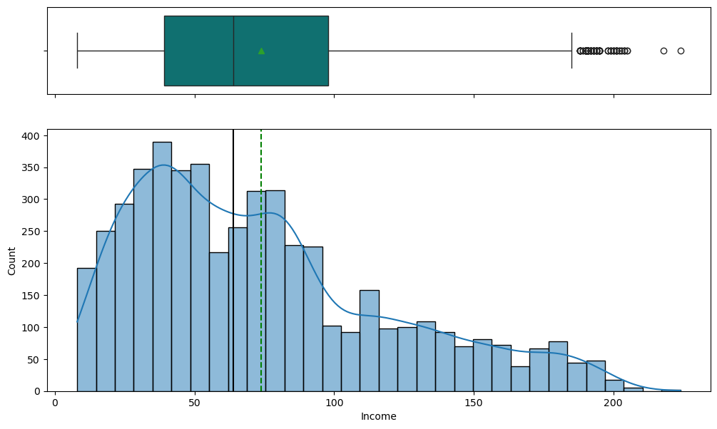

```python
histogram_boxplot(df, "Income")
```

##### Observation :

The graph is slightly right skewed. Most of the datapoints fall in the lower income region indicating most of the individuals in the dataset draw a low income

#### Observations on Age

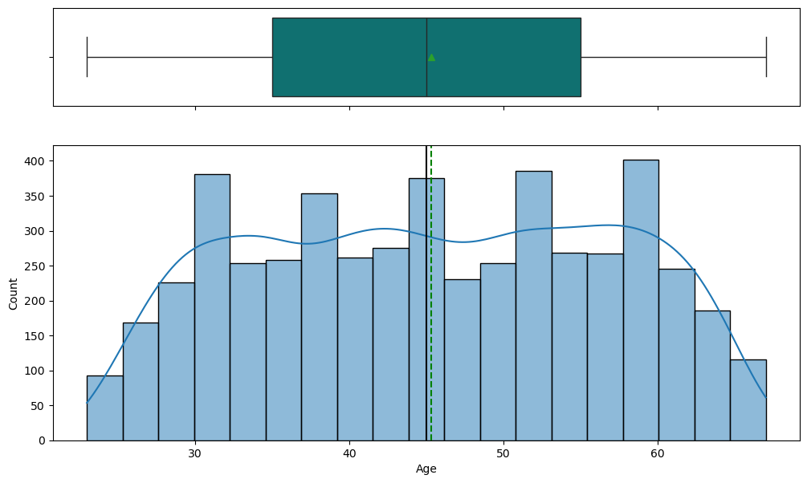

```python
histogram_boxplot(df, "Age")
```

##### Observation :

Follows a normal distribution with the mean and median very close to each other The box plot shows no outliers

#### Observations on Experience

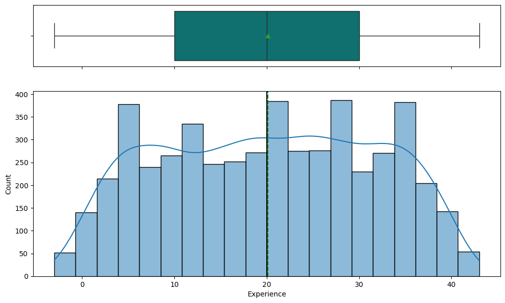

```python
histogram_boxplot(df, "Experience")
```

##### Observation :

Experience Follows a normal distribution. Mean and Median overlap with each other indicating a symmetric distribution. There are no outliers in the dataset

#### Observations on CCAvg

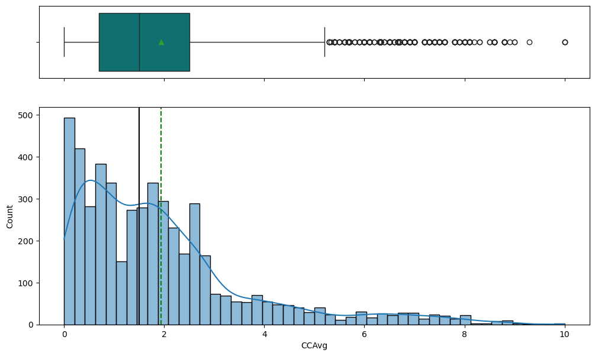

```python
histogram_boxplot(df, "CCAvg")
```

##### Observation :

Graph is right skewed which indicates that most of the customers have a below average credit card usage. However, there seem to be a lot of outliers

#### Observations on Mortgage

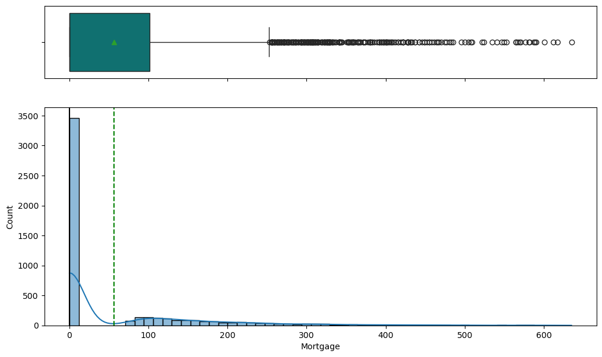

```python
histogram_boxplot(df, "Mortgage")
```

#### Observations on Family

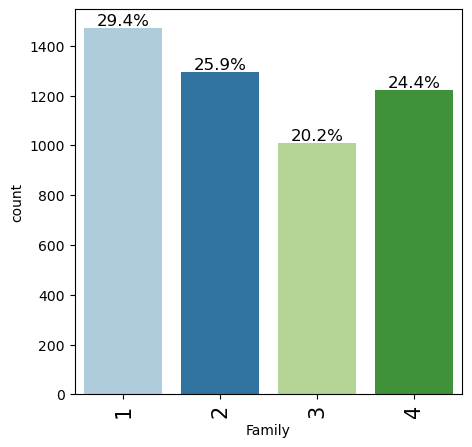

```python
labeled_barplot(df, "Family",perc=True)
```

##### Observation :

Almost 29% of the families have max 1 member in the family followed by families with 2 and 4 members  
3 member families are the least in number

#### Observations on Education

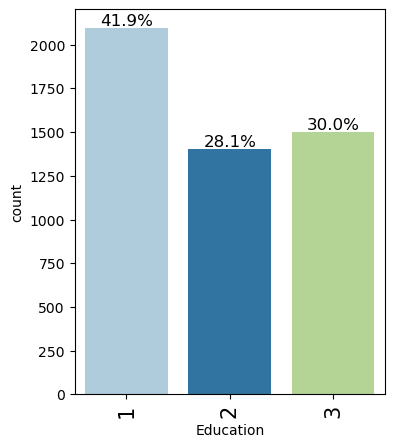

```python
labeled_barplot(df, "Education",perc=True)
```

##### Observation :

Almost 42% of the customers are UnderGrads.  
Around 30% of customers are Professionals  
Nearly 28% of customers are Graduates

#### Observations on Securities Account

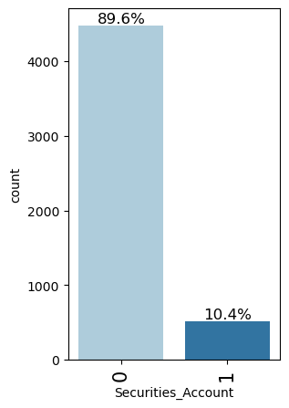

```python
labeled_barplot(df, "Securities_Account",perc=True)
```

##### Observation :

Most of the customers do not have a securities account with the bank(89.6%). 10% of the customers have a securities account with the bank

#### Observations on CD Account

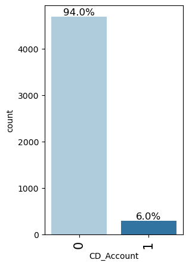

```python
labeled_barplot(df, "CD_Account",perc=True)
```

##### Observation :

Most of the customers do not have a Certificate of Deposit with the bank (94%). Only 6% of the customers have a CD account with the bank

#### Observations on Online

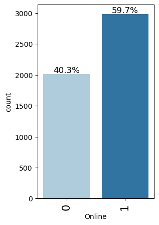

```python
labeled_barplot(df, "Online",perc=True)
```

##### Observation :

60% of the customers use internet banking. 40% do not use internet banking

#### Observations on Credit Card

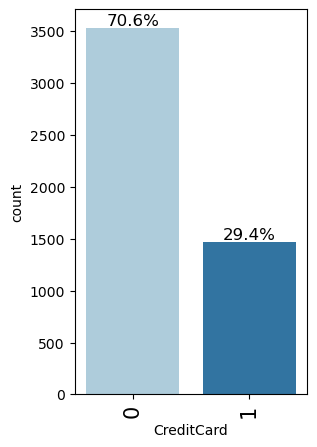

```python
labeled_barplot(df, "CreditCard",perc=True)
```

##### Observation :

Around 70% of All Life Bank customers do not use credit cards issued by other banks Remaining 30% use credit cards from multiple banks

#### Observations on ZipCode

```python
labeled_barplot(df, "ZIPCode", perc=True)
```

[figure not shown]

## Bivariate Analysis

Defining the Functions for EDA - Bivariate Analysis - Bar Plot and Distribution plot

```python
def stacked_barplot(data, predictor, target):
    """
    Print the category counts and plot a stacked bar chart

    data: dataframe
    predictor: independent variable
    target: target variable
    """
    count = data[predictor].nunique()
    sorter = data[target].value_counts().index[-1]
    tab1 = pd.crosstab(data[predictor], data[target], margins=True).sort_values(
        by=sorter, ascending=False
    )
    print(tab1)
    print("-" * 120)
    tab = pd.crosstab(data[predictor], data[target], normalize="index").sort_values(
        by=sorter, ascending=False
    )
    tab.plot(kind="bar", stacked=True, figsize=(count + 5, 5), cmap='crest')
    plt.legend(
        loc="lower left", frameon=False,
    )
    plt.legend(loc="upper left", bbox_to_anchor=(1, 1))
    plt.show()
```

```python
def distribution_plot_wrt_target(data, predictor, target):

    fig, axs = plt.subplots(2, 2, figsize=(12, 10))

    target_uniq = data[target].unique()

    axs[0, 0].set_title("Distribution of Personal Loan for Personal Loan=" + str(target_uniq[0]))
    sns.histplot(
        data=data[data[target] == target_uniq[0]],
        x=predictor,
        kde=True,
        ax=axs[0, 0],
        color="teal",
        stat="density",
    )

    axs[0, 1].set_title("Distribution of Personal Loan for Personal Loan=" + str(target_uniq[1]))
    sns.histplot(
        data=data[data[target] == target_uniq[1]],
        x=predictor,
        kde=True,
        ax=axs[0, 1],
        color="aquamarine",
        stat="density",
    )

    axs[1, 0].set_title("Boxplot w.r.t Personal Loan")
    sns.boxplot(data=data, x=target, y=predictor, ax=axs[1, 0], showmeans=True, palette="crest")

    axs[1, 1].set_title("Boxplot (without outliers) w.r.t Personal Loan")
    sns.boxplot(
        data=data,
        x=target,
        y=predictor,
        ax=axs[1, 1],
        showfliers=False,
        showmeans=True,
        palette="crest",
    )

    plt.tight_layout()
    plt.show()
```

#### Personal_Loan vs Education

```
Personal_Loan     0    1   All
Education
All            4520  480  5000
3              1296  205  1501
2              1221  182  1403
1              2003   93  2096
------------------------------------------------------------------------------------------------------------------------
```

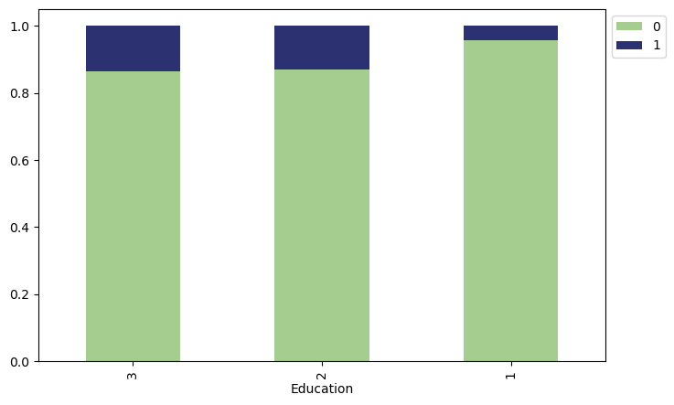

```python
stacked_barplot(df, "Education", "Personal_Loan")
```

##### Observation :

Out of 5000 customers, 480 customers accepted the loan, that is around 9.6% Of the 480 customers who accepted the loan, 205 customers had Education level3 (Highest - Professionals) which is around 42.7% Of the 480 customers who accepted the loan, 182 customers had Education level2 (Graduates) which is around 37.9% Of the 480 customers who accepted the loan, 93 customers had Education level1 (Undergrads) which is around 19.4%

Customers with highest education level tend to take the maximum number of personal loans

#### Personal_Loan vs Family

```
Personal_Loan     0    1   All
Family
All            4520  480  5000
4              1088  134  1222
3               877  133  1010
1              1365  107  1472
2              1190  106  1296
------------------------------------------------------------------------------------------------------------------------
```

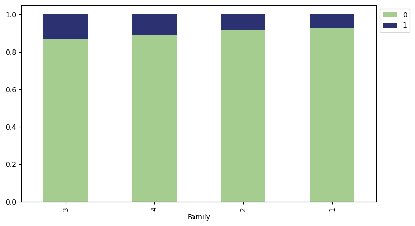

```python
stacked_barplot(df, "Family", "Personal_Loan")
```

##### Observation:

Out of 5000 customers, 480 customers accepted the loan, that is around 9.6% Customers with Family size 4 have an acceptance rate (134 out of 1222) around 10.9% Customers with Family size 3 have an acceptance rate (133 out of 1010) around 13.2% Customers with Family size 2 have an acceptance rate (106 out of 1296) around 8.2% Customers with Family size 1 have an acceptance rate (107 out of 1472) around 7.3%

Customers with Family size 3 have the highest acceptance rate and Customers with Family size 1 have the least acceptance rate Customers with Family size 1 and 2 have almost similar acceptance rate and is lower than that of customers with higher family size. This indicates that people tend to take more loans when the family size increases

#### Personal_Loan vs Securities Account

```
Personal_Loan          0    1   All
Securities_Account
All                 4520  480  5000
0                   4058  420  4478
1                    462   60   522
------------------------------------------------------------------------------------------------------------------------
```

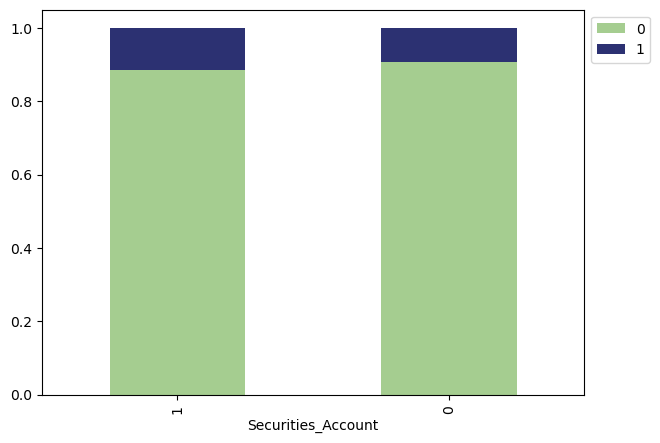

```python
stacked_barplot(df, "Securities_Account", "Personal_Loan")
```

##### Observation :

Out of 5000 customers, 522 customers hold a securities account with the bank, which is around 10.4% Out of 522 customers that hold a securities account with the bank, 60 have accepted the loan, which is around 11.5% Out of 4478 customers that do not have a securities account with the bank, 420 have accepted the loan, which is around 9.3%

This indicates that holding a securities account with the bank does not have any much significance towards the loan acceptance

#### Personal_Loan vs CD Account

```
Personal_Loan     0    1   All
CD_Account
All            4520  480  5000
0              4358  340  4698
1               162  140   302
------------------------------------------------------------------------------------------------------------------------
```

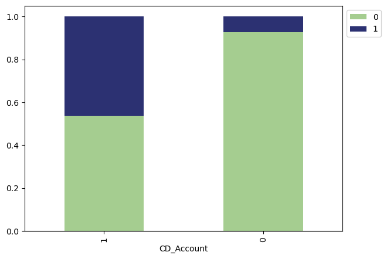

```python
stacked_barplot(df, "CD_Account", "Personal_Loan")
```

##### Observation :

Out of 5000 customers, 302 customers have a CD account, that is around 6% Out of 302 customers who have a CD account with the bank, 140 have accepted the loan which is around 46.3% Out of 4698 customers who do not have a CD account with the bank, 340 have accepted the loan which is around 7.2%

This indicates that, holding a CD account with the bank increases the tendency to accept a loan

#### Personal_Loan vs Credit Card

```
Personal_Loan     0    1   All
CreditCard
All            4520  480  5000
0              3193  337  3530
1              1327  143  1470
------------------------------------------------------------------------------------------------------------------------
```

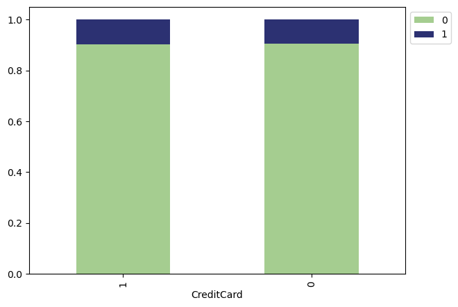

```python
stacked_barplot(df, "CreditCard", "Personal_Loan")
```

##### Observation :

Out of 5000 customers, 3530 customers do not hold a credit card issued by a different bank which is around 70.6%  
Out of 3530 customers who own only a credit card issued by AllLife Bank, 337 have acceptaed the loan which is around 9.5%  
Out of 1470 customers who own a credit card issued by a different bank, 143 have accepted the loan which is around 9.7%

This indicates that holding multiple bank credit cards or credit card of only AllLife Bank does not make an impact on the personal loan acceptance rate

#### Personal_Loan vs Online

```
Personal_Loan     0    1   All
Online
All            4520  480  5000
1              2693  291  2984
0              1827  189  2016
------------------------------------------------------------------------------------------------------------------------
```

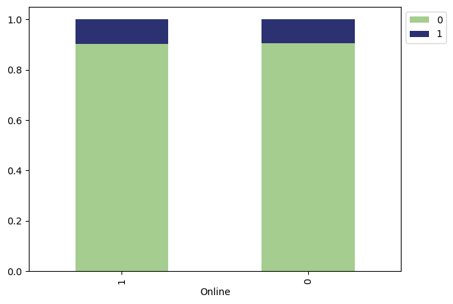

```python
stacked_barplot(df, "Online", "Personal_Loan")
```

##### Observations:

Out of 5000 customers, 2984 customers use internet banking which is around 59.7% Out of 2984 customers who use internet banking, 291 have accepted the loan which is around 9.8% Out of 2016 customers who do not use internet banking, 189 have accepted the loan which is around 9.4%

This indicates that internet banking usage does not make an impact on the personal loan acceptance rate

#### Personal_Loan vs ZIPCode

```python
stacked_barplot(df, "ZIPCode", "Personal_Loan")
```

```
Personal_Loan     0    1   All
ZIPCode
All            4520  480  5000
94720           150   19   169
94305           114   13   127
92093            42    9    51
90095            63    8    71
...             ...  ...   ...
92866             8    0     8
92843             3    0     3
92835             3    0     3
92833             4    0     4
90005             5    0     5

[468 rows x 3 columns]
------------------------------------------------------------------------------------------------------------------------
```

[figure not shown]

##### Observation:

This indicates that location or zipcode of the customer does not impact the personal loan acceptance rate. However, one fourth of the customers who accepted the loan were residing in Zipcode starting with 95.

#### Personal_Loan vs Age

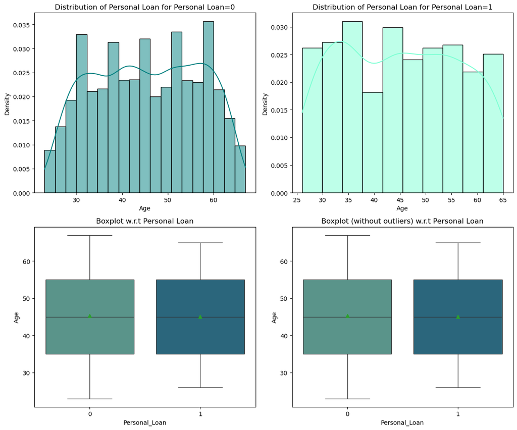

```python
distribution_plot_wrt_target(df, "Age", "Personal_Loan")
```

##### Observation :

The Mean and Median Age overlap for both categories of Personal loan indicating a normal distribution for both categories The similar box plot for the 2 categories indicate that distribution of Age is uniform irrespective of whether the individual has taken the loan or not Absence of outliers indicate there are no extreme values for Age Age of customer is not a strong influencer in personal loan acceptance decision

#### Personal_Loan vs CCAvg

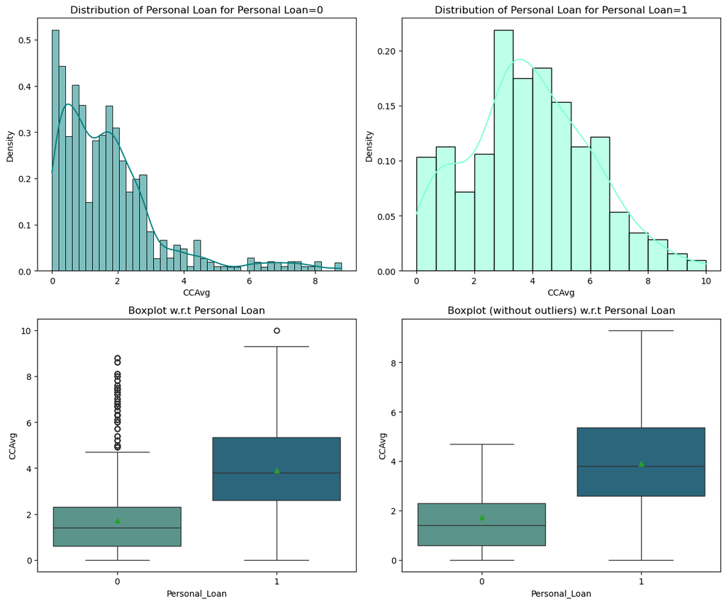

```python
distribution_plot_wrt_target(df, "CCAvg", "Personal_Loan")
```

#### Personal_Loan vs Experience

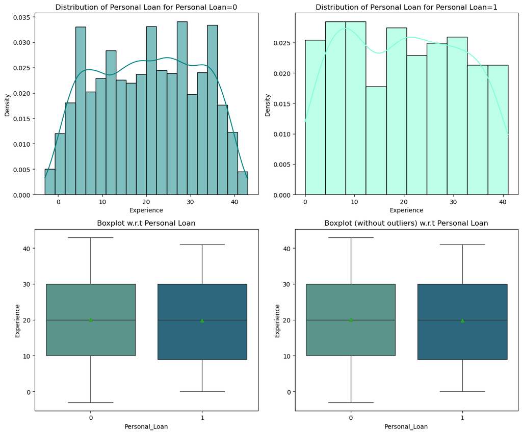

```python
distribution_plot_wrt_target(df, "Experience", "Personal_Loan")
```

##### Observation :

The Mean and Median Experience overlap for both categories of Personal loan indicating a normal distribution for both categories The similar box plot for the 2 categories indicate that distribution ofExperiencee is uniform irrespective of whether the individual has taken the loan or no Absence of outliers indicate there are no extreme values foExperience ExperienceAge of customer is not a strong influencer in personal loan acceptance decision

#### Personal_Loan vs Income

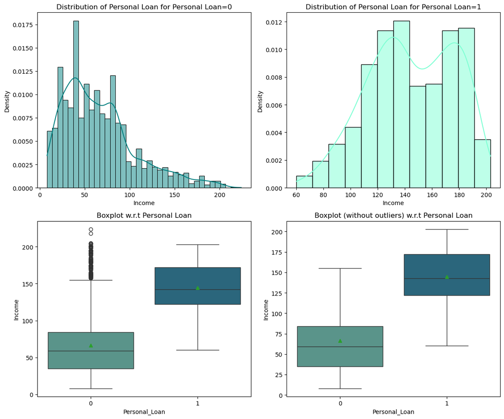

```python
distribution_plot_wrt_target(df, "Income", "Personal_Loan")
```

##### Observation :

For the customers who have not taken a personal loan, the Income graph is slightly right skewed There are lot of outliers for this category which explains the skewness. This indicates that lot of customers fall under the low income category For customers who have taken a personal loan, the Income graph has a uniform distribution Absence of outliers and overlap of mean and median indicate a normal distribution IQR ranges of the two categories indicate that customers with higher Income are more likely to accept a personal loan

### Correlation Check

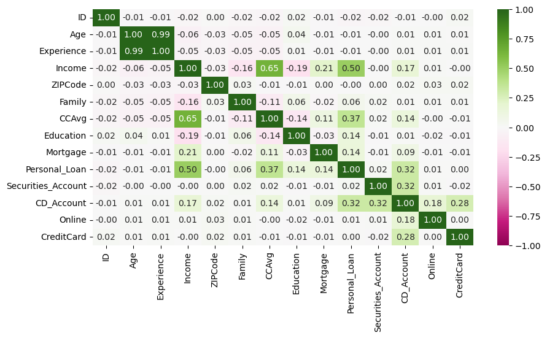

```python
# Correlation for only numeric columns
plt.figure(figsize=(10, 5))
sns.heatmap(df.corr(numeric_only=True), annot=True, vmin=-1, vmax=1, fmt=".2f", cmap="PiYG") # Complete the code to get the heatmap of the data
plt.show()
```

##### Observation

Age and Experience are almost perfectly correlated.. Hence, one of the columns can be dropped CCAvg and Income have high positive correlation. As income increases, the Average spend also increases Mortgage has a weak positive correlation with income and CCAvg. As income increases the investments increase leading to increase in mortgage

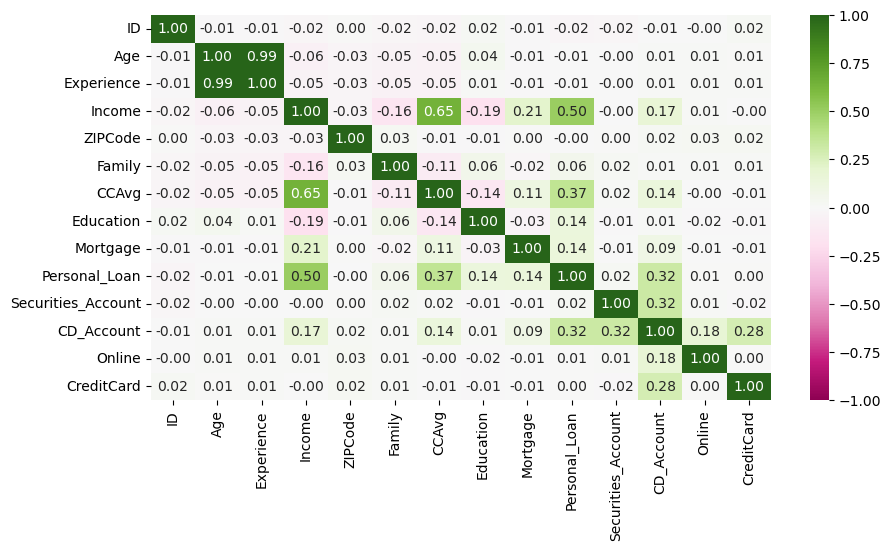

```python
# Crrelation for all columns
plt.figure(figsize=(10, 5))
sns.heatmap(df.corr(), annot=True, vmin=-1, vmax=1, fmt=".2f", cmap="PiYG") # Complete the code to get the heatmap of the data
plt.show()
```

##### Observations :

Income and Personal_Loan have a correlation of 0.5 CCAvg and Personal_Loan have a correlation of 0.37 CD_Account and Personal_Loan have a correlation of 0.32

Apart from these, Education and Mortgage have a weak correlation of 0.14 with Personal_Loan

```python
# CreditCard: Does the customer use a credit card issued by any other Bank (excluding All life Bank)? (0: No, 1: Yes)
cc_counts = df["CreditCard"].value_counts()
cc_counts
```

```
CreditCard
0    3530
1    1470
Name: count, dtype: int64
```

**Questions**:

1. What is the distribution of mortgage attribute? Are there any noticeable patterns or outliers in the distribution?
2. How many customers have credit cards?
3. What are the attributes that have a strong correlation with the target attribute (personal loan)?
4. How does a customer's interest in purchasing a loan vary with their age?
5. How does a customer's interest in purchasing a loan vary with their education?

##### Ans #1: What is the distribution of mortgage attribute? Are there any noticeable patterns or outliers in the distribution?

Mortgage distribution is heavily right skewed. The median overlaps with the lower Quartile. Most of the customers have 0-10K mortgage. Few customers have exceptionally high mortgage values resulting in large number of outliers on the upper quartile side Few customers have mortgage between 80-110K

##### Ans #2: How many customers have credit cards?

1470 Customers have Credit Cards issued by other banks.

##### Ans #3: What are the attributes that have a strong correlation with the target attribute (personal loan)?

Income and Personal_Loan have a correlation of 0.5 CCAvg and Personal_Loan have a correlation of 0.37 CD_Account and Personal_Loan have a correlation of 0.32

Apart from these, Education and Mortgage have a weak correlation of 0.14 with Personal_Loan

##### Ans #4: How does a customer's interest in purchasing a loan vary with their age?

The Mean and Median Age overlap for both categories of Personal loan indicating a normal distribution for both categories The similar box plot for the 2 categories indicate that distribution of Age is uniform irrespective of whether the individual has taken the loan or not Absence of outliers indicate there are no extreme values for Age

##### Ans #5: How does a customer's interest in purchasing a loan vary with their education?

Out of 5000 customers, 480 customers accepted the loan, that is around 9.6% Of the 480 customers who accepted the loan, 205 customers had Education level3 (Highest - Professionals) which is around 42.7% Of the 480 customers who accepted the loan, 182 customers had Education level2 (Graduates) which is around 37.9% Of the 480 customers who accepted the loan, 93 customers had Education level1 (Undergrads) which is around 19.4%

Customers with highest education level tend to take the maximum number of personal loans

## Data Preprocessing

- Missing value treatment
- Feature engineering (if needed)
- Outlier detection and treatment (if needed)
- Preparing data for modeling
- Any other preprocessing steps (if needed)

ID is not a data dense column and can be dropped from analysis

### Drop ID

```python
df = df.drop("ID", axis=1)
```

### Missing value treatment

```python
df.isnull().sum()
```

```
Age                   0
Experience            0
Income                0
ZIPCode               0
Family                0
CCAvg                 0
Education             0
Mortgage              0
Personal_Loan         0
Securities_Account    0
CD_Account            0
Online                0
CreditCard            0
dtype: int64
```

##### Observation:

There are no missing values in the dataset

### Checking for duplicate values

```python
df.duplicated().sum()
```

```
0
```

##### Observations:

There are no duplicate values in the data.

### Checking for Anomalous Values in data

```python
# checking for experience <0
df[df["Experience"] < 0]["Experience"].unique()
```

```
array([-1, -2, -3], dtype=int64)
```

```python
# Correcting the experience values
df["Experience"].replace(-1, 1, inplace=True)
df["Experience"].replace(-2, 2, inplace=True)
df["Experience"].replace(-3, 3, inplace=True)
```

##### Observations:

Assuming the negative values in Experience column as data errors, they are replaced with absolute values

```python
# Checking values for Zipcode
df["ZIPCode"].nunique()
```

```
467
```

##### Observations:

```python
df["ZIPCode"] = [int(np.round(i/1000)) for i in df["ZIPCode"]]
df.head()
```

|  | Age | Experience | Income | ZIPCode | Family | CCAvg | Education | Mortgage | Personal_Loan | Securities_Account | CD_Account | Online | CreditCard |
| --- | --- | --- | --- | --- | --- | --- | --- | --- | --- | --- | --- | --- | --- |
| 0 | 25 | 1 | 49 | 91 | 4 | 1.6 | 1 | 0 | 0 | 1 | 0 | 0 | 0 |
| 1 | 45 | 19 | 34 | 90 | 3 | 1.5 | 1 | 0 | 0 | 1 | 0 | 0 | 0 |
| 2 | 39 | 15 | 11 | 95 | 1 | 1.0 | 1 | 0 | 0 | 0 | 0 | 0 | 0 |
| 3 | 35 | 9 | 100 | 94 | 1 | 2.7 | 2 | 0 | 0 | 0 | 0 | 0 | 0 |
| 4 | 35 | 8 | 45 | 91 | 4 | 1.0 | 2 | 0 | 0 | 0 | 0 | 0 | 1 |

```python
# The numerical values for Education are not actually valid integers. They representsatives for some categories.
# Hence converting them back to categories for better understandability
```

```python
# Replacing 1 with 'Undergraduate', 2 with 'Graduate' and 3 with 'Professional'
df["Education"].replace(1, "Undergraduate", inplace=True)
df["Education"].replace(2, "Graduate", inplace=True)
df["Education"].replace(3, "Professional", inplace=True)
```

```python
# Checking the values for Education
df["Education"].unique()
```

```
array(['Undergraduate', 'Graduate', 'Professional'], dtype=object)
```

```python
# "Personal_Loan", "Securities_Account", "CD_Account", "Online", "CreditCard" are columns that take Yes/No values.
# Hence, are actually categorical columns. "Education", "ZIPCode" have numerical values.
# But, the numerical values do not represent actual value. Hence, needs to be converted to categorical value
```

```python
## Converting the data type of categorical features to 'category'
col = [
    "Education",
    "ZIPCode",
    "Securities_Account",
    "CD_Account",
    "Online",
    "CreditCard",
    "Personal_Loan"
]
df[col] = df[col].astype("category")
df.info()
```

```
<class 'pandas.core.frame.DataFrame'>
RangeIndex: 5000 entries, 0 to 4999
Data columns (total 13 columns):
 #   Column              Non-Null Count  Dtype
---  ------              --------------  -----
 0   Age                 5000 non-null   int64
 1   Experience          5000 non-null   int64
 2   Income              5000 non-null   int64
 3   ZIPCode             5000 non-null   category
 4   Family              5000 non-null   int64
 5   CCAvg               5000 non-null   float64
 6   Education           5000 non-null   category
 7   Mortgage            5000 non-null   int64
 8   Personal_Loan       5000 non-null   category
 9   Securities_Account  5000 non-null   category
 10  CD_Account          5000 non-null   category
 11  Online              5000 non-null   category
 12  CreditCard          5000 non-null   category
dtypes: category(7), float64(1), int64(5)
memory usage: 269.8 KB
```

### Outlier Detection and treatment

```python
Q1 = df.select_dtypes(include=["float64", "int64"]).quantile(0.25)  # To find the 25th percentile and 75th percentile.
Q3 = df.select_dtypes(include=["float64", "int64"]).quantile(0.75)

IQR = Q3 - Q1  # Inter Quantile Range (75th perentile - 25th percentile)

lower = (
    Q1 - 1.5 * IQR
)  # Finding lower and upper bounds for all values. All values outside these bounds are outliers
upper = Q3 + 1.5 * IQR
```

```python
((df.select_dtypes(include=["float64", "int64"]) < lower)
    | (df.select_dtypes(include=["float64", "int64"]) > upper)
).sum() / len(df) * 100
```

```
Age           0.00
Experience    0.00
Income        1.92
Family        0.00
CCAvg         6.48
Mortgage      5.82
dtype: float64
```

##### Observation :

Income has 1.92% outliers  
CCAvg has 6.48% outliers  
Mortgage has 5.82% outliers  
Age, Experience, Family have 0 outliers

### Data Preparation for Modeling

```python
# "Personal_Loan", "Securities_Account", "CD_Account", "Online", "CreditCard" categorical columns are already convered to numerical values in the dataset
# "Education", "ZIPCode" have to be converted to numrical values
```

```python
X = df.drop(["Personal_Loan","Experience"], axis=1)
y = df["Personal_Loan"]

X = pd.get_dummies(X, columns=["ZIPCode", "Education"], drop_first=True)

# Splitting data in train and test sets
X_train, X_test, y_train, y_test = train_test_split(
    X, y, test_size=0.30, stratify=y, random_state=42
)
```

```python
print("Shape of Training set : ", X_train.shape)
print("Shape of test set : ", X_test.shape)
print("Percentage of classes in training set:")
print(y_train.value_counts(normalize=True))
print("Percentage of classes in test set:")
print(y_test.value_counts(normalize=True))
```

```
Shape of Training set :  (3500, 18)
Shape of test set :  (1500, 18)
Percentage of classes in training set:
Personal_Loan
0    0.904
1    0.096
Name: proportion, dtype: float64
Percentage of classes in test set:
Personal_Loan
0    0.904
1    0.096
Name: proportion, dtype: float64
```

## Model Building

### Model Evaluation Criterion

- We will create a baseline model with DecisionTreeClassifier with classWeights = balanced
- We will train the default model on training data set
- We will test the model on the test data set
- We will Improve the performance of the model with pre-pruning and post-pruning

### Model Building

```python
# defining a function to compute different metrics to check performance of a classification model built using sklearn
def model_performance_classification_sklearn(model, predictors, target):
    """
    Function to compute different metrics to check classification model performance

    model: classifier
    predictors: independent variables
    target: dependent variable
    """

    # predicting using the independent variables
    pred = model.predict(predictors)

    acc = accuracy_score(target, pred)  # to compute Accuracy
    recall = recall_score(target, pred)  # to compute Recall
    precision = precision_score(target, pred)  # to compute Precision
    f1 = f1_score(target, pred)  # to compute F1-score

    # creating a dataframe of metrics
    df_perf = pd.DataFrame(
        {"Accuracy": acc, "Recall": recall, "Precision": precision, "F1": f1,},
        index=[0],
    )

    return df_perf
```

```python
def confusion_matrix_sklearn(model, predictors, target):
    """
    To plot the confusion_matrix with percentages

    model: classifier
    predictors: independent variables
    target: dependent variable
    """
    y_pred = model.predict(predictors)
    cm = confusion_matrix(target, y_pred)
    labels = np.asarray(
        [
            ["{0:0.0f}".format(item) + "\n{0:.2%}".format(item / cm.flatten().sum())]
            for item in cm.flatten()
        ]
    ).reshape(2, 2)

    plt.figure(figsize=(6, 4))
    sns.heatmap(cm, annot=labels, fmt="")
    plt.ylabel("True label")
    plt.xlabel("Predicted label")
```

### Decision Tree (sklearn default) with class_weight=balanced

```python
model = DecisionTreeClassifier(criterion="gini", random_state=1, class_weight='balanced')
model.fit(X_train, y_train)
```

```
DecisionTreeClassifier(class_weight='balanced', random_state=1)
```

### Checking model performance on training data

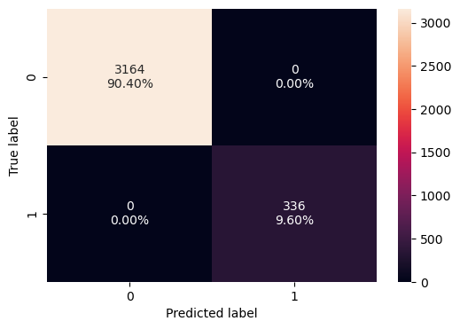

```python
confusion_matrix_sklearn(model, X_train, y_train)
```

```python
decision_tree_perf_train = model_performance_classification_sklearn(
    model, X_train, y_train
)
decision_tree_perf_train
```

|  | Accuracy | Recall | Precision | F1 |
| --- | --- | --- | --- | --- |
| 0 | 1.0 | 1.0 | 1.0 | 1.0 |

##### Observations

All scores are perfect 1 indicating the model is overfitting on training data

#### Visualizing the Decision Tree

```python
feature_names = list(X_train.columns)
print(feature_names)
```

```
['Age', 'Income', 'Family', 'CCAvg', 'Mortgage', 'Securities_Account', 'CD_Account', 'Online', 'CreditCard', 'ZIPCode_91', 'ZIPCode_92', 'ZIPCode_93', 'ZIPCode_94', 'ZIPCode_95', 'ZIPCode_96', 'ZIPCode_97', 'Education_Professional', 'Education_Undergraduate']
```

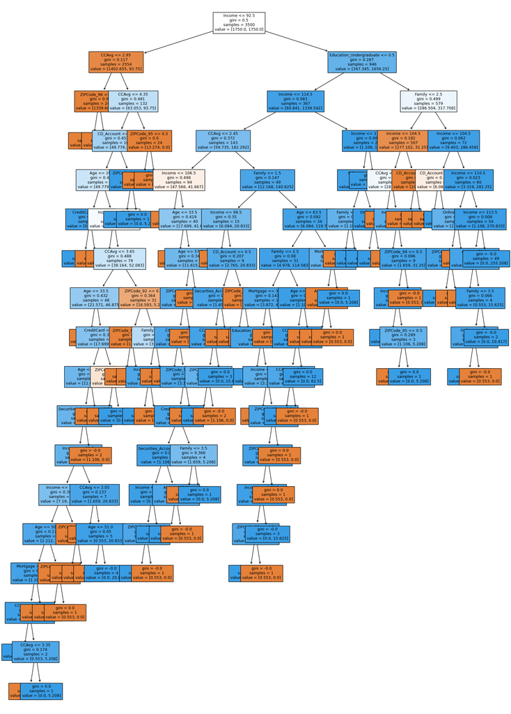

```python
plt.figure(figsize=(20, 30))
out = tree.plot_tree(
    model,
    feature_names=feature_names,
    filled=True,
    fontsize=9,
    node_ids=False,
    class_names=None,
)
# below code will add arrows to the decision tree split if they are missing
for o in out:
    arrow = o.arrow_patch
    if arrow is not None:
        arrow.set_edgecolor("black")
        arrow.set_linewidth(1)
plt.show()
```

```python
# Text report showing the rules of a decision tree -

print(tree.export_text(model, feature_names=feature_names, show_weights=True))
```

```
|--- Income <= 92.50
|   |--- CCAvg <= 2.95
|   |   |--- ZIPCode_96 <= 0.50
|   |   |   |--- weights: [1206.31, 0.00] class: 0
|   |   |--- ZIPCode_96 >  0.50
|   |   |   |--- weights: [133.30, 0.00] class: 0
|   |--- CCAvg >  2.95
|   |   |--- CCAvg <= 4.35
|   |   |   |--- CD_Account <= 0.50
|   |   |   |   |--- Age <= 29.50
|   |   |   |   |   |--- CreditCard <= 0.50
|   |   |   |   |   |   |--- weights: [0.00, 15.62] class: 1
|   |   |   |   |   |--- CreditCard >  0.50
|   |   |   |   |   |   |--- weights: [0.55, 0.00] class: 0
|   |   |   |   |--- Age >  29.50
|   |   |   |   |   |--- Income <= 63.50
|   |   |   |   |   |   |--- weights: [11.06, 0.00] class: 0
|   |   |   |   |   |--- Income >  63.50
|   |   |   |   |   |   |--- CCAvg <= 3.65
|   |   |   |   |   |   |   |--- Age <= 33.50
|   |   |   |   |   |   |   |   |--- weights: [3.87, 0.00] class: 0
|   |   |   |   |   |   |   |--- Age >  33.50
|   |   |   |   |   |   |   |   |--- CreditCard <= 0.50
|   |   |   |   |   |   |   |   |   |--- Age <= 60.50
|   |   |   |   |   |   |   |   |   |   |--- Securities_Account <= 0.50
|   |   |   |   |   |   |   |   |   |   |   |--- truncated branch of depth 7
|   |   |   |   |   |   |   |   |   |   |--- Securities_Account >  0.50
|   |   |   |   |   |   |   |   |   |   |   |--- weights: [1.11, 0.00] class: 0
|   |   |   |   |   |   |   |   |   |--- Age >  60.50
|   |   |   |   |   |   |   |   |   |   |--- weights: [1.11, 0.00] class: 0
|   |   |   |   |   |   |   |   |--- CreditCard >  0.50
|   |   |   |   |   |   |   |   |   |--- ZIPCode_94 <= 0.50
|   |   |   |   |   |   |   |   |   |   |--- weights: [6.64, 0.00] class: 0
|   |   |   |   |   |   |   |   |   |--- ZIPCode_94 >  0.50
|   |   |   |   |   |   |   |   |   |   |--- weights: [0.00, 5.21] class: 1
|   |   |   |   |   |   |--- CCAvg >  3.65
|   |   |   |   |   |   |   |--- ZIPCode_92 <= 0.50
|   |   |   |   |   |   |   |   |--- ZIPCode_93 <= 0.50
|   |   |   |   |   |   |   |   |   |--- weights: [9.40, 0.00] class: 0
|   |   |   |   |   |   |   |   |--- ZIPCode_93 >  0.50
```

[output cut: 153 more lines]

```
|   |   |   |   |   |   |--- weights: [1.66, 0.00] class: 0
|   |   |   |   |--- Income >  110.50
|   |   |   |   |   |--- Income <= 113.50
|   |   |   |   |   |   |--- Age <= 33.00
|   |   |   |   |   |   |   |--- weights: [0.55, 0.00] class: 0
|   |   |   |   |   |   |--- Age >  33.00
|   |   |   |   |   |   |   |--- Family <= 3.50
|   |   |   |   |   |   |   |   |--- Online <= 0.50
|   |   |   |   |   |   |   |   |   |--- weights: [0.00, 5.21] class: 1
|   |   |   |   |   |   |   |   |--- Online >  0.50
|   |   |   |   |   |   |   |   |   |--- weights: [0.55, 0.00] class: 0
|   |   |   |   |   |   |   |--- Family >  3.50
|   |   |   |   |   |   |   |   |--- weights: [0.00, 10.42] class: 1
|   |   |   |   |   |--- Income >  113.50
|   |   |   |   |   |   |--- weights: [0.00, 255.21] class: 1
```

```python
# importance of features in the tree building ( The importance of a feature is computed as the
# (normalized) total reduction of the criterion brought by that feature. It is also known as the Gini importance )

print(
    pd.DataFrame(
        model.feature_importances_, columns=["Imp"], index=X_train.columns
    ).sort_values(by="Imp", ascending=False)
)
```

```
                              Imp
Income                   0.631953
Family                   0.134859
CCAvg                    0.095795
Education_Undergraduate  0.089467
Age                      0.017971
CD_Account               0.008614
ZIPCode_94               0.004958
ZIPCode_92               0.003399
CreditCard               0.002267
ZIPCode_95               0.002186
Mortgage                 0.002173
Online                   0.002057
ZIPCode_91               0.001496
Securities_Account       0.001432
ZIPCode_93               0.000556
ZIPCode_96               0.000549
Education_Professional   0.000270
ZIPCode_97               0.000000
```

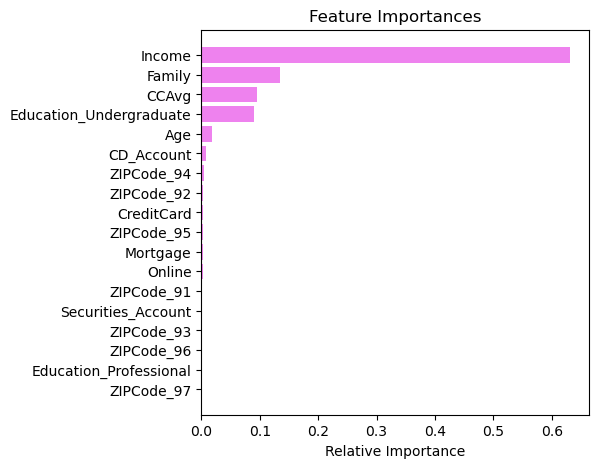

```python
# Plotting Feature Importance
importances = model.feature_importances_
indices = np.argsort(importances)

plt.figure(figsize=(5, 5))
plt.title("Feature Importances")
plt.barh(range(len(indices)), importances[indices], color="violet", align="center")
plt.yticks(range(len(indices)), [feature_names[i] for i in indices])
plt.xlabel("Relative Importance")
plt.show()
```

##### Observation :

For the default decision tree Income, Family, CCAvg, Education_Undergraduate are the most important features affecting the target variable

#### Checking model performance on test data

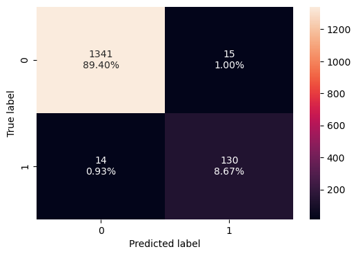

```python
confusion_matrix_sklearn(model, X_test, y_test)
```

```python
decision_tree_perf_test = model_performance_classification_sklearn(
    model, X_test, y_test
)
decision_tree_perf_test
```

|  | Accuracy | Recall | Precision | F1 |
| --- | --- | --- | --- | --- |
| 0 | 0.980667 | 0.902778 | 0.896552 | 0.899654 |

##### Observation:

The reduction in Recall value from Training set to Test set indicates overfitting.  
The model is able to predict well on training set, but unable to generalise on unseen data

## Model Performance Improvement

### Pre-Pruning with class_weight=balanced

```python
# Define the parameters of the tree to iterate over
max_depth_values = np.arange(2, 7, 2)
max_leaf_nodes_values = [50, 75, 150, 250]
min_samples_split_values = [10, 30, 50, 70]

# Initialize variables to store the best model and its performance
best_estimator = None
best_score_diff = float('inf')
best_test_score = 0.0

# Iterate over all combinations of the specified parameter values
for max_depth in max_depth_values:
    for max_leaf_nodes in max_leaf_nodes_values:
        for min_samples_split in min_samples_split_values:

            # Initialize the tree with the current set of parameters
            estimator = DecisionTreeClassifier(
                max_depth=max_depth,
                max_leaf_nodes=max_leaf_nodes,
                min_samples_split=min_samples_split,
                class_weight='balanced',
                random_state=1
            )

            # Fit the model to the training data
            estimator.fit(X_train, y_train)

            # Make predictions on the training and test sets
            y_train_pred = estimator.predict(X_train)
            y_test_pred = estimator.predict(X_test)

            # Calculate recall scores for training and test sets
            train_recall_score = recall_score(y_train, y_train_pred)
            test_recall_score = recall_score(y_test, y_test_pred)

            # Calculate the absolute difference between training and test recall scores
            score_diff = abs(train_recall_score - test_recall_score)

            # Update the best estimator and best score if the current one has a smaller score difference
            if (score_diff < best_score_diff) & (test_recall_score > best_test_score):
                best_score_diff = score_diff
                best_test_score = test_recall_score
                best_estimator = estimator

# Print the best parameters
print("Best parameters found:")
print(f"Max depth: {best_estimator.max_depth}")
print(f"Max leaf nodes: {best_estimator.max_leaf_nodes}")
print(f"Min samples split: {best_estimator.min_samples_split}")
print(f"Best test recall score: {best_test_score}")
```

```
Best parameters found:
Max depth: 2
Max leaf nodes: 50
Min samples split: 10
Best test recall score: 1.0
```

```python
# Fit the best algorithm to the data.
estimator = best_estimator
estimator.fit(X_train, y_train)
```

```
DecisionTreeClassifier(class_weight='balanced', max_depth=2, max_leaf_nodes=50,
                       min_samples_split=10, random_state=1)
```

#### Checking performance on training data

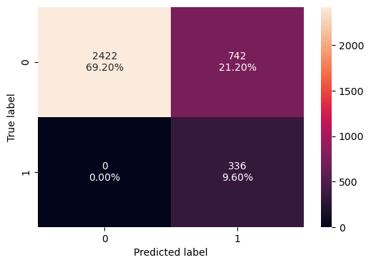

```python
confusion_matrix_sklearn(estimator, X_train, y_train)
```

```python
decision_tree_tune_perf_train = model_performance_classification_sklearn(estimator, X_train, y_train)
decision_tree_tune_perf_train
```

|  | Accuracy | Recall | Precision | F1 |
| --- | --- | --- | --- | --- |
| 0 | 0.788 | 1.0 | 0.311688 | 0.475248 |

##### Observation :

Model is abe to predict well on training set as recall score is 1.  
There are no False Negatives predicted by the model. However, the other metrics are pretty low  
The model ha predicted 21% false positives

#### Visualizing the Decision Tree

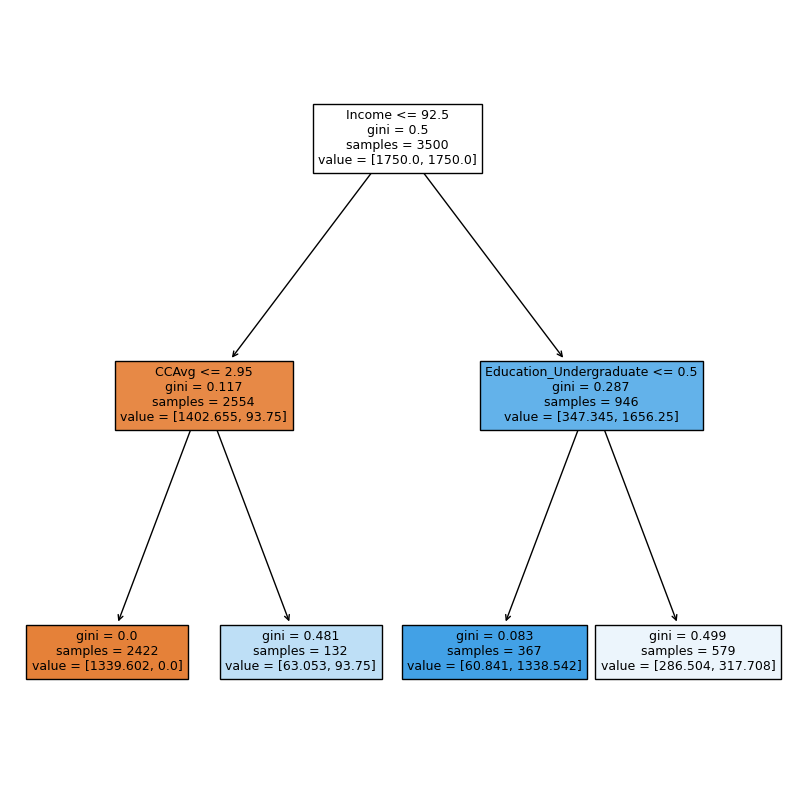

```python
plt.figure(figsize=(10, 10))
out = tree.plot_tree(
    estimator,
    feature_names=feature_names,
    filled=True,
    fontsize=9,
    node_ids=False,
    class_names=None,
)
# below code will add arrows to the decision tree split if they are missing
for o in out:
    arrow = o.arrow_patch
    if arrow is not None:
        arrow.set_edgecolor("black")
        arrow.set_linewidth(1)
plt.show()
```

```python
# Text report showing the rules of a decision tree -

print(tree.export_text(estimator, feature_names=feature_names, show_weights=True))
```

```
|--- Income <= 92.50
|   |--- CCAvg <= 2.95
|   |   |--- weights: [1339.60, 0.00] class: 0
|   |--- CCAvg >  2.95
|   |   |--- weights: [63.05, 93.75] class: 1
|--- Income >  92.50
|   |--- Education_Undergraduate <= 0.50
|   |   |--- weights: [60.84, 1338.54] class: 1
|   |--- Education_Undergraduate >  0.50
|   |   |--- weights: [286.50, 317.71] class: 1
```

```python
# importance of features in the tree building ( The importance of a feature is computed as the
# (normalized) total reduction of the criterion brought by that feature. It is also known as the Gini importance )

print(
    pd.DataFrame(
        estimator.feature_importances_, columns=["Imp"], index=X_train.columns
    ).sort_values(by="Imp", ascending=False)
)
```

```
                              Imp
Income                   0.795592
Education_Undergraduate  0.124564
CCAvg                    0.079844
ZIPCode_92               0.000000
Education_Professional   0.000000
ZIPCode_97               0.000000
ZIPCode_96               0.000000
ZIPCode_95               0.000000
ZIPCode_94               0.000000
ZIPCode_93               0.000000
Age                      0.000000
CreditCard               0.000000
Online                   0.000000
CD_Account               0.000000
Securities_Account       0.000000
Mortgage                 0.000000
Family                   0.000000
ZIPCode_91               0.000000
```

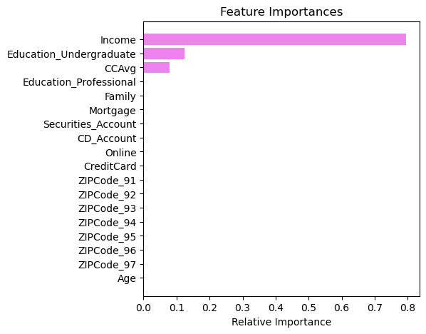

```python
importances = estimator.feature_importances_
indices = np.argsort(importances)

plt.figure(figsize=(5, 5))
plt.title("Feature Importances")
plt.barh(range(len(indices)), importances[indices], color="violet", align="center")
plt.yticks(range(len(indices)), [feature_names[i] for i in indices])
plt.xlabel("Relative Importance")
plt.show()
```

##### Observation :

Income, Education_Undergraduate and CCAvg are the most importnt features affecting the target variable

#### Checking performance on test data

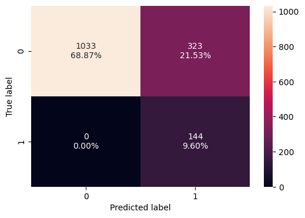

```python
confusion_matrix_sklearn(estimator, X_test, y_test)
```

```python
decision_tree_tune_perf_test = model_performance_classification_sklearn(estimator, X_test, y_test)
decision_tree_tune_perf_test
```

|  | Accuracy | Recall | Precision | F1 |
| --- | --- | --- | --- | --- |
| 0 | 0.784667 | 1.0 | 0.308351 | 0.471358 |

##### Observation :

Model is abe to predict well on training set as recall score is 1.  
There are no False Negatives predicted by the model. However, the other metrics are pretty low.  
The model has predicted 21% False Positives which is not efficient